# Hrushikesh_DayanandaSagarCollegeOfEngineering_1DS19EC717

# China Country Analysis

### Data Preparation

```python
df_china=data[data.Country == 'China'].drop('Country',axis = 1).set_index('Date').astype(int)
df_china.head()
```

| Date | Value |
| --- | --- |
| 2019-01-01 | 6788150 |
| 2019-02-01 | 2946702 |
| 2019-03-01 | 10384100 |
| 2019-04-01 | 6349899 |
| 2019-05-01 | 6910464 |

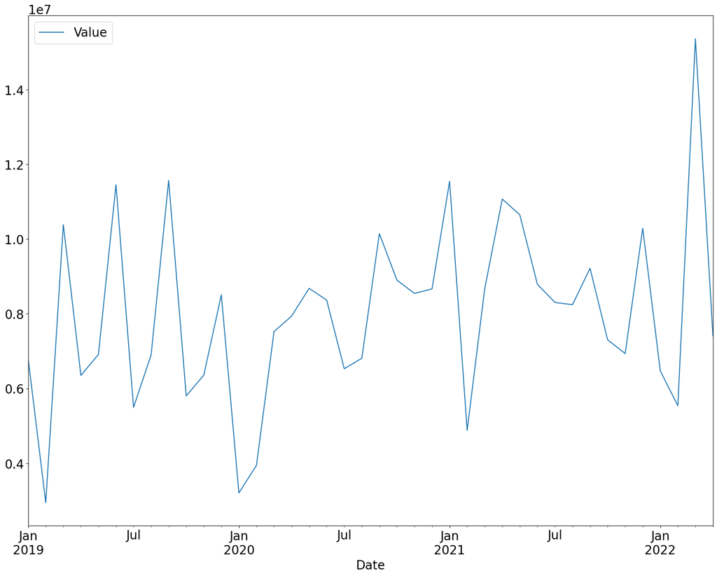

```python
df_china.plot()
plt.show()
```

### Seasonal Decomposition Of Data

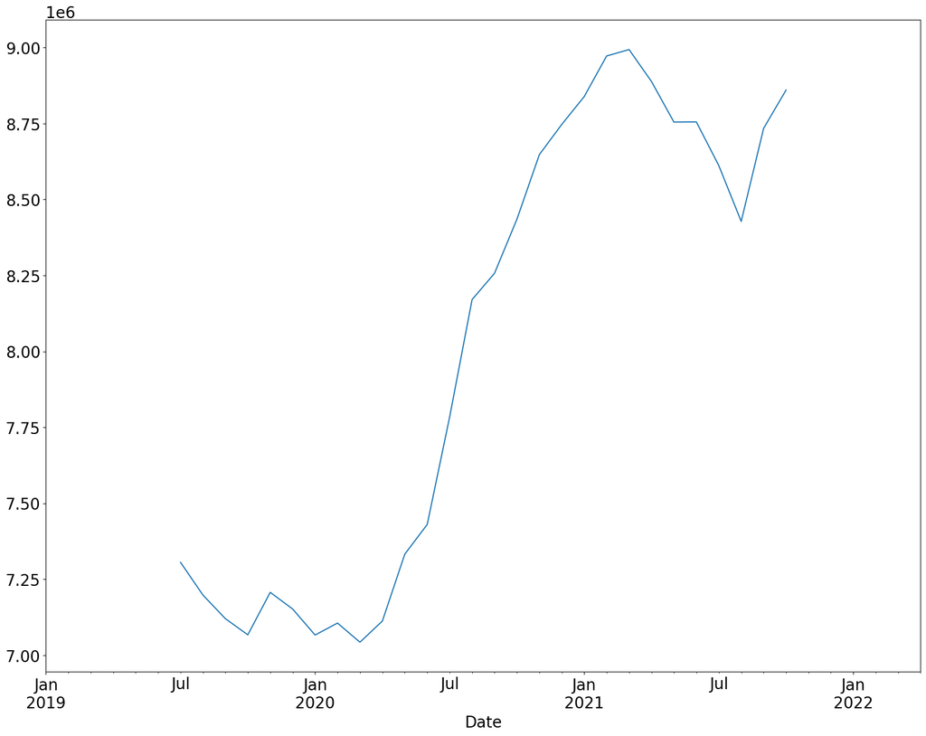

```python
decomposition = seasonal_decompose(df_china['Value'] , model = 'additive')
decomposition.trend.plot()

plt.show()
```

### Check For Stationarity :- A D-Fuller Test

```python
result = sts.adfuller(df_china['Value'])
print(f'ADF Statistic : {result[0]}')
print(f'n_lags: {result[2]}')
print(f'p_value: {result[1]}')

for key , value in result[4].items():
    print('Critical Values :')
    print(f'{key} , {value}')
```

```
ADF Statistic : -2.2874894967374475
n_lags: 2
p_value: 0.1760346093385453
Critical Values :
1% , -3.6209175221605827
Critical Values :
5% , -2.9435394610388332
Critical Values :
10% , -2.6104002410518627
```

**Since p_value > 0.05 We can't reject the Null Hypotheses that Data is Non-Stationary**  
**Therefore Data is Non-Stationary** **Let's take the Difference of the values**

**Formula to calculate difference from original values**

**$ diff_{t} = value_{t} - value_{t-1} $**

```python
df_china['Diff_Value'] = df_china['Value'].diff()
df_china.head()
```

| Date | Value | Diff_Value |
| --- | --- | --- |
| 2019-01-01 | 6788150 | NaN |
| 2019-02-01 | 2946702 | -3841448.0 |
| 2019-03-01 | 10384100 | 7437398.0 |
| 2019-04-01 | 6349899 | -4034201.0 |
| 2019-05-01 | 6910464 | 560565.0 |

```python
result = sts.adfuller(df_china['Diff_Value'][1:])
print(f'ADF Statistic : {result[0]}')
print(f'n_lags: {result[2]}')
print(f'p_value: {result[1]}')

for key , value in result[4].items():
    print('Critical Values :')
    print(f'{key} , {value}')
```

```
ADF Statistic : -11.664623367147085
n_lags: 1
p_value: 1.8972127201653653e-21
Critical Values :
1% , -3.6209175221605827
Critical Values :
5% , -2.9435394610388332
Critical Values :
10% , -2.6104002410518627
```

**Since p_value < 0.05 We reject the Null Hypotheses that Data is Non-Stationary**  
**Therefore Data is Stationary**

### Auto Correlation Function

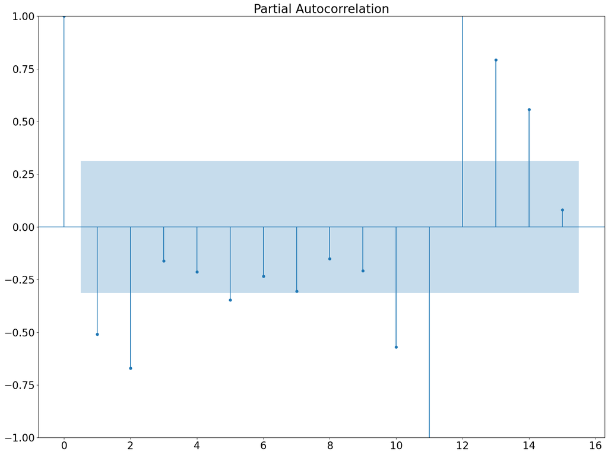

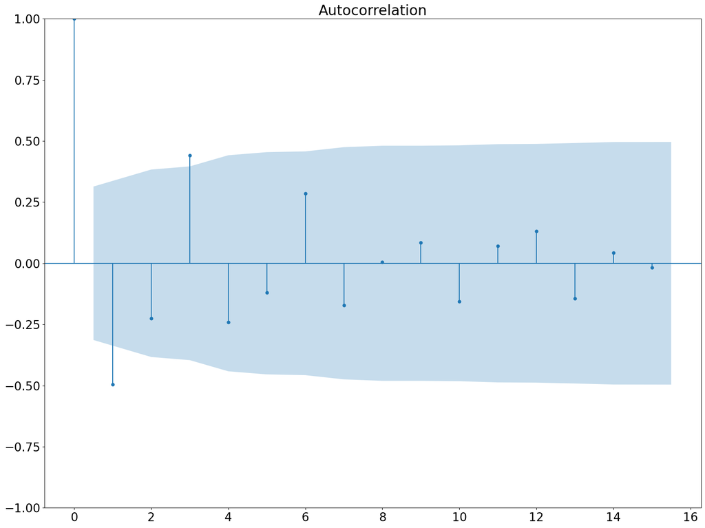

```python
plot_pacf(df_china['Diff_Value'][1:] ,  lags = 15)
plot_acf(df_china['Diff_Value'][1:] ,  lags = 15)
plt.show()
```

**By see the pacf and acf plots we can have these pairs of orders for ARIMA model :- (1,0,1) , (1,0,3) , (2,0,1) , (2,0,3)**

### Finding The Suitable Model

```python
orders = [(1,0,1) , (1,0,3) , (2,0,1) , (2,0,3)]

for order in orders:
    ar,ma = order[0] , order[-1]
    arima = ARIMA(df_china['Diff_Value'][1:] , order = (ar,0,ma))
    results = arima.fit()
    print(f'ARIMA{order} has LLF = {results.llf} and AIC = {results.aic}')
```

```
ARIMA(1, 0, 1) has LLF = -631.2465571565734 and AIC = 1270.4931143131469
ARIMA(1, 0, 3) has LLF = -628.287353875275 and AIC = 1268.57470775055
ARIMA(2, 0, 1) has LLF = -627.0101968416868 and AIC = 1264.0203936833736
ARIMA(2, 0, 3) has LLF = -623.8643908241062 and AIC = 1261.7287816482124
```

**We can choose ARIMA(2,0,3)**

```python
arima_203 = ARIMA(df_china['Diff_Value'][1:] , order = (2,0,3))
results_203 = arima_203.fit()
```

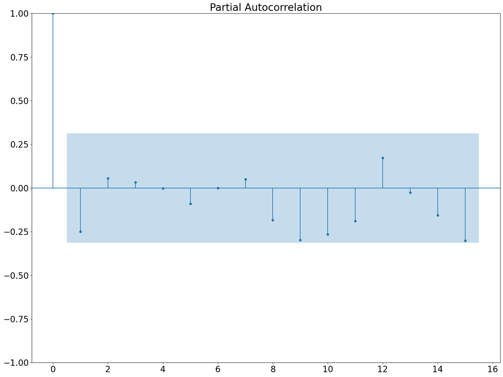

```python
plot_pacf(results_203.resid , lags = 15)
plt.show()

#we can proceed since there are no lags
```

### Forecasting Future Values

```python
# Lets forecast for next 15 months
differences = results_203.forecast(steps = 15).values.tolist()

# Store the data values for calculating values from forecast values
values = df_china['Value'].values.tolist()
len(values)
```

```
40
```

**Formula to calculate original values from differences**

**$ value_{t} = diff_{t} + value_{t-1} $**

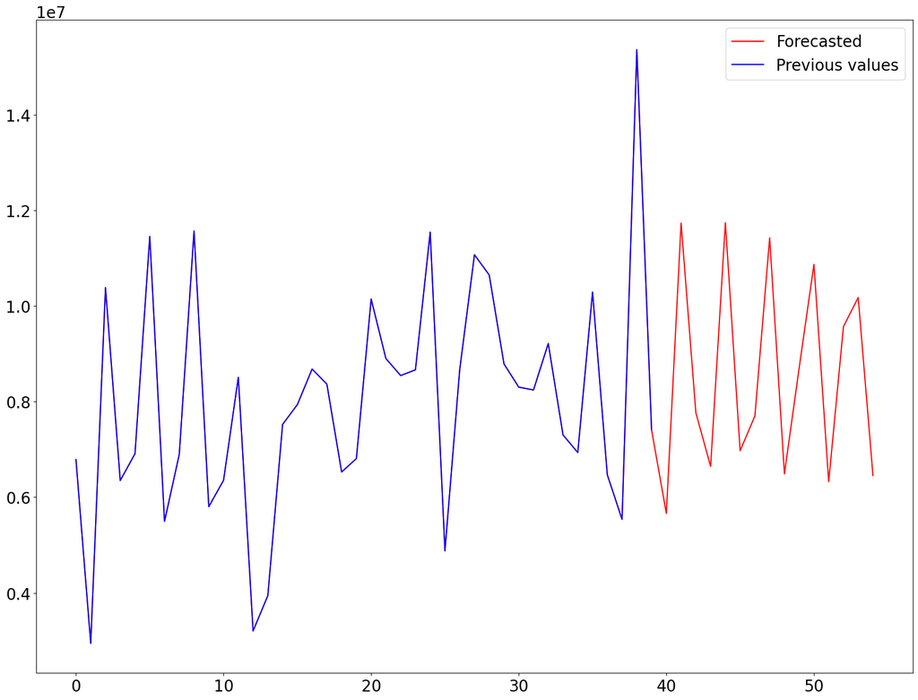

```python
for diff in differences:
    val = diff + values[-1]
    values.append(round(val))

plt.plot(values , label = 'Forecasted' , color = 'red')
plt.plot(df_china['Value'].values , label = 'Previous values' ,color = 'blue')
plt.legend()
plt.show()
```

```python
forecast_df['China'] = values[40:]
```

```python
# joblib.dump(results_203 , 'Model_China.pkl')
```

[output not shown]

# Germany Country Analysis

### Data Preparation

```python
df_germany=data[data.Country == 'Germany'].drop('Country',axis = 1).set_index('Date').astype(int)
df_germany.head()
```

| Date | Value |
| --- | --- |
| 2019-01-01 | 37362308 |
| 2019-02-01 | 23448750 |
| 2019-03-01 | 41479346 |
| 2019-04-01 | 26591457 |
| 2019-05-01 | 21957327 |

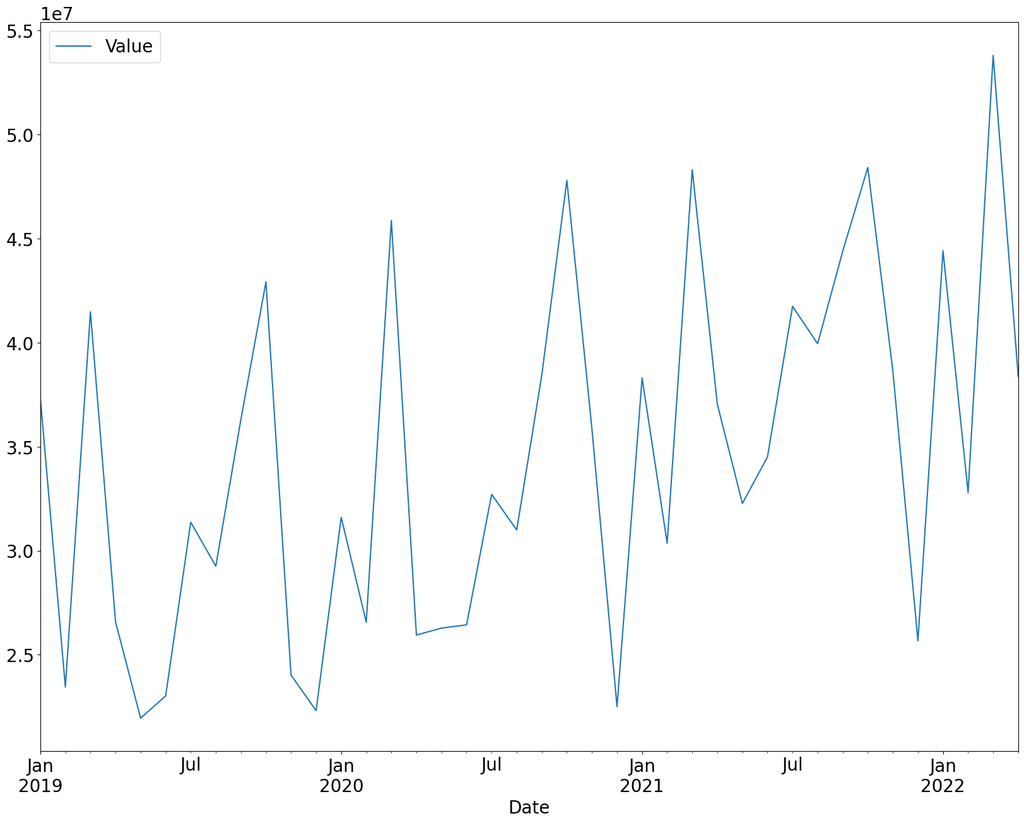

```python
df_germany.plot()
```

### Seasonal Decomposition Of Data

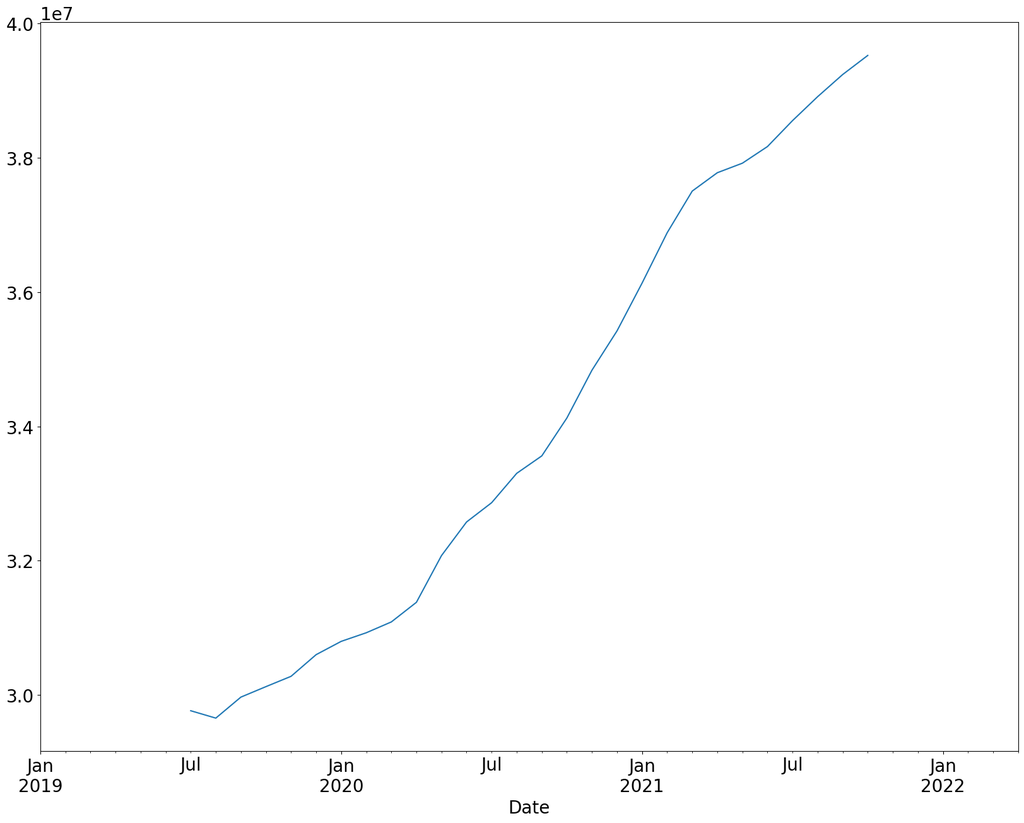

```python
decomposition = seasonal_decompose(df_germany['Value'] , model = 'additive')
decomposition.trend.plot()

plt.show()
```

### Check For Stationarity :- A D-Fuller Test

```python
result = sts.adfuller(df_germany['Value'])
print(f'ADF Statistic : {result[0]}')
print(f'n_lags: {result[2]}')
print(f'p_value: {result[1]}')

for key , value in result[4].items():
    print('Critical Values :')
    print(f'{key} , {value}')
```

```
ADF Statistic : -0.7093420524695137
n_lags: 6
p_value: 0.8443148731922288
Critical Values :
1% , -3.6461350877925254
Critical Values :
5% , -2.954126991123355
Critical Values :
10% , -2.6159676124885216
```

**Since p_value > 0.05 We can't reject the Null Hypotheses that Data is Non-Stationary**  
**Therefore Data is Non-Stationary** **Let's take the Returns of the values**

### Creating Returns and Plotting ACF

```python
# Since Taking Difference didn't worked well on forecasting i choose to use Returns
```

```python
df_germany['Return'] = df_germany['Value'].pct_change(1).mul(100)
df_germany.head()
```

| Date | Value | Return |
| --- | --- | --- |
| 2019-01-01 | 37362308 | NaN |
| 2019-02-01 | 23448750 | -37.239557 |
| 2019-03-01 | 41479346 | 76.893634 |
| 2019-04-01 | 26591457 | -35.892294 |
| 2019-05-01 | 21957327 | -17.427138 |

```python
result = sts.adfuller(df_germany['Return'][1:])
print(f'ADF Statistic : {result[0]}')
print(f'n_lags: {result[2]}')
print(f'p_value: {result[1]}')

for key , value in result[4].items():
    print('Critical Values :')
    print(f'{key} , {value}')
```

```
ADF Statistic : -5.500007743348371
n_lags: 10
p_value: 2.0815346300135427e-06
Critical Values :
1% , -3.6889256286443146
Critical Values :
5% , -2.9719894897959187
Critical Values :
10% , -2.6252957653061224
```

**Since p_value < 0.05 We reject the Null Hypotheses that Data is Non-Stationary**  
**Therefore Data is Stationary**

### Auto Correlation Function

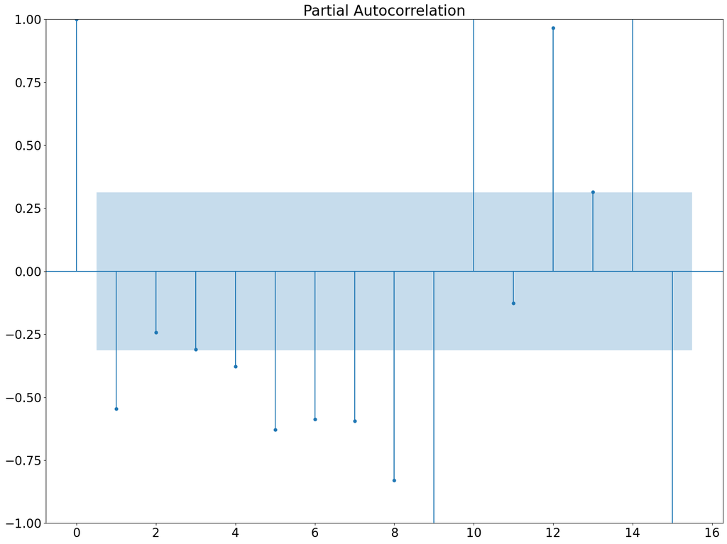

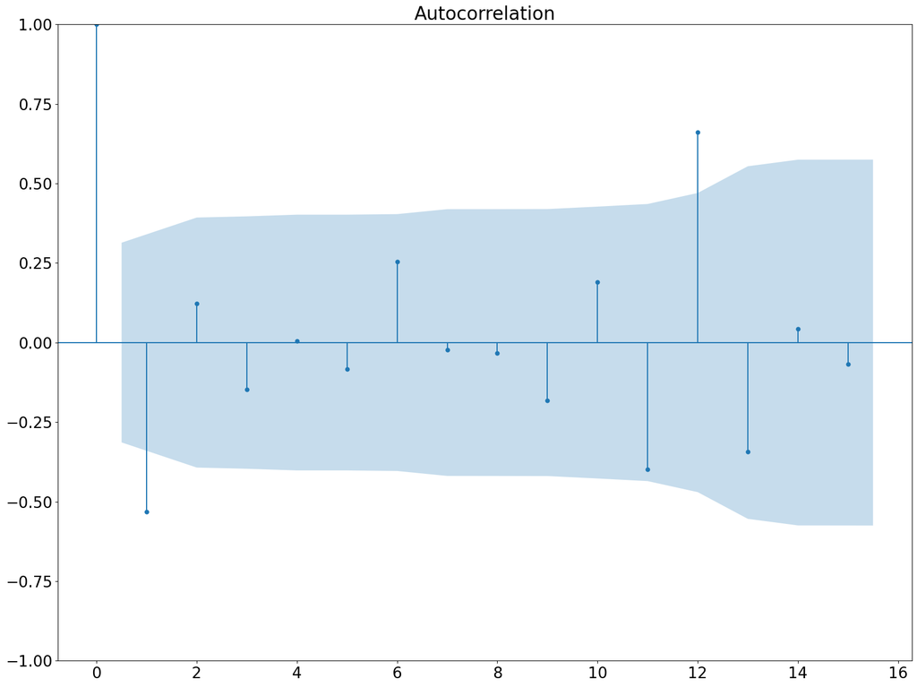

```python
plot_pacf(df_germany['Return'][1:] ,  lags = 15)
plot_acf(df_germany['Return'][1:] ,  lags = 15)
plt.show()
```

The possible pairs of orders for ARIMA model can be :-  
(1,0,0) , (0,0,1) , (1,0,1) , (4,0,0) , (4,0,1) , (5,0,0) , (5,0,1) , (6,0,0) , (6,0,1)

### Finding The Suitable Model

```python
orders= [(1,0,0) , (0,0,1) , (1,0,1) , (4,0,0) , (4,0,1) , (5,0,0) , (5,0,1) , (6,0,0) , (6,0,1)]

for order in orders:
    ar,ma = order[0] , order[-1]
    arima = ARIMA(df_germany['Return'][1:] , order = (ar,0,ma))
    results = arima.fit()
    print(f'ARIMA{order} has LLF = {results.llf} and AIC = {results.aic}')
```

```
ARIMA(1, 0, 0) has LLF = -187.06878000262245 and AIC = 380.1375600052449
ARIMA(0, 0, 1) has LLF = -179.7117141464951 and AIC = 365.4234282929902
ARIMA(1, 0, 1) has LLF = -179.4098852441754 and AIC = 366.8197704883508
ARIMA(4, 0, 0) has LLF = -182.53618223437437 and AIC = 377.07236446874873
ARIMA(4, 0, 1) has LLF = -175.95024141097068 and AIC = 365.90048282194135
ARIMA(5, 0, 0) has LLF = -175.20848917644122 and AIC = 364.41697835288244
ARIMA(5, 0, 1) has LLF = -173.90023287147974 and AIC = 363.8004657429595
ARIMA(6, 0, 0) has LLF = -173.46849229752104 and AIC = 362.9369845950421
ARIMA(6, 0, 1) has LLF = -173.40147566529757 and AIC = 364.80295133059514
```

**After making some analysis let's choose ARIMA(5,0,0)**

```python
arima_500 = ARIMA(df_germany['Return'][1:] , order = (5,0,0))
results_500 = arima_500.fit()
```

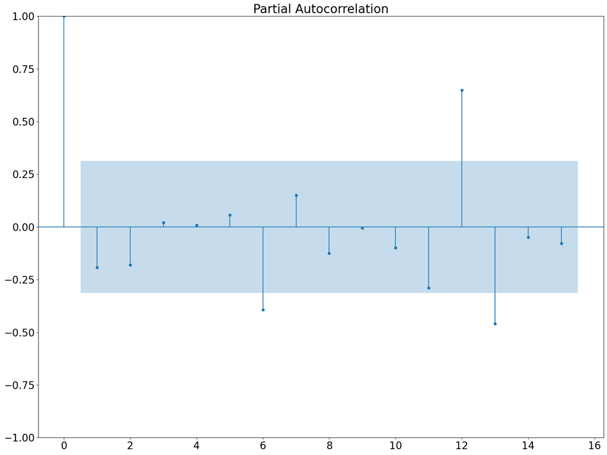

```python
plot_pacf(results_500.resid , lags = 15)
plt.show()

#we can ignore that 6 because even if we take ARIMA(6,0,0) it will be present
```

### Forecasting Future Values

```python
# Lets forecast for next 15 months
returns = results_500.forecast(steps = 15).values.tolist()

# Store the data values for calculating values from forecasted values
values = df_germany['Value'].values.tolist()
len(values)
```

```
40
```

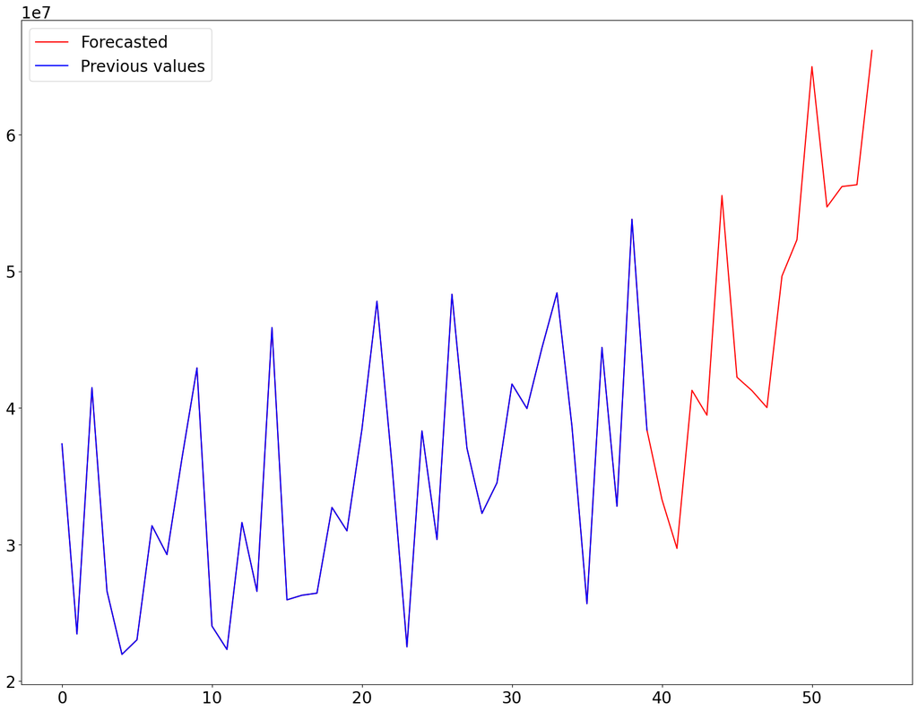

```python
for ret in returns:
    ret = ret/100
    last = values[-1]
    res = (last*ret)+last
    values.append(round(res))

plt.plot(values , label = 'Forecasted' , color = 'red')
plt.plot(df_germany['Value'].values , label = 'Previous values' ,color = 'blue')
plt.legend()
plt.show()
```

```python
forecast_df['Germany'] = values[40:]
```

```python
# joblib.dump(results_500 , 'Model_Germany.pkl')
```

[output not shown]

# USA Country Analysis

### Data Preparation

```python
df_usa=data[data.Country == 'USA'].drop('Country',axis = 1).set_index('Date').astype(int)
df_usa.head()
```

| Date | Value |
| --- | --- |
| 2019-01-01 | 27164329 |
| 2019-02-01 | 24954357 |
| 2019-03-01 | 25969580 |
| 2019-04-01 | 30632226 |
| 2019-05-01 | 32710665 |

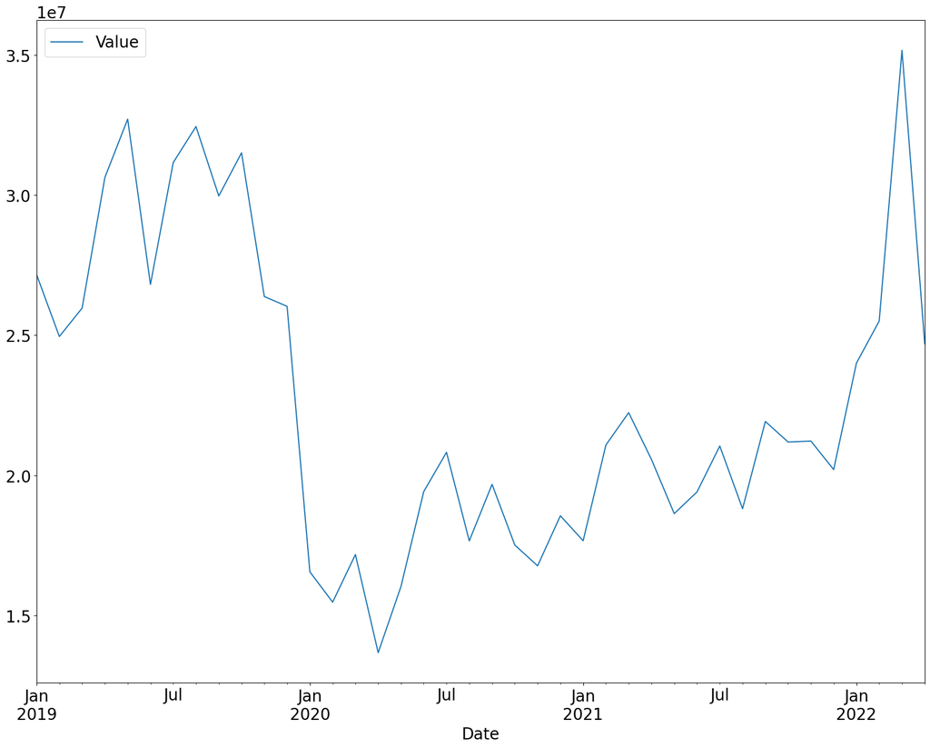

```python
df_usa.plot()
plt.show()
```

### Seasonal Decomposition Of Data

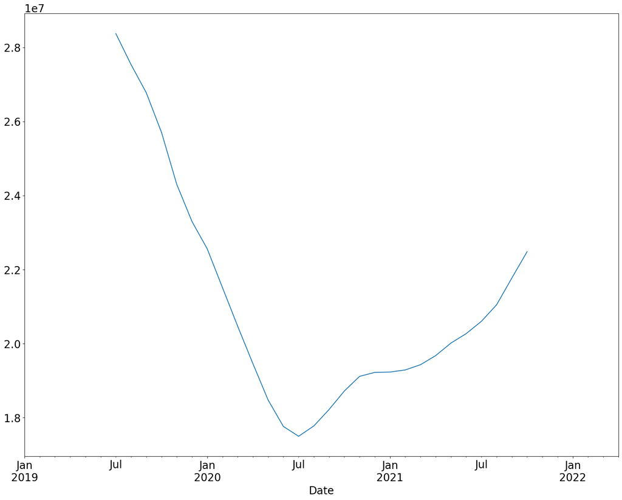

```python
decomposition = seasonal_decompose(df_usa['Value'] , model = 'additive')
decomposition.trend.plot()

plt.show()
```

### Check For Stationarity :- A D-Fuller Test

```python
result = sts.adfuller(df_usa['Value'])
print(f'ADF Statistic : {result[0]}')
print(f'n_lags: {result[2]}')
print(f'p_value: {result[1]}')

for key , value in result[4].items():
    print('Critical Values :')
    print(f'{key} , {value}')
```

```
ADF Statistic : -2.2523103517450207
n_lags: 0
p_value: 0.1878101659124256
Critical Values :
1% , -3.610399601308181
Critical Values :
5% , -2.939108945868946
Critical Values :
10% , -2.6080629651545038
```

Since p_value > 0.05 We can't reject the Null Hypotheses that Data is Non-Stationary  
Therefore Data is Non-Stationary  
Let's take the Difference of the values.  
Since single level difference don't have any degree of similarity  
we will make two level difference

```python
df_usa['Diff_Value'] = df_usa['Value'].diff(2)
df_usa.head()
```

| Date | Value | Diff_Value |
| --- | --- | --- |
| 2019-01-01 | 27164329 | NaN |
| 2019-02-01 | 24954357 | NaN |
| 2019-03-01 | 25969580 | -1194749.0 |
| 2019-04-01 | 30632226 | 5677869.0 |
| 2019-05-01 | 32710665 | 6741085.0 |

```python
result = sts.adfuller(df_usa['Diff_Value'][2:])
print(f'ADF Statistic : {result[0]}')
print(f'n_lags: {result[2]}')
print(f'p_value: {result[1]}')

for key , value in result[4].items():
    print('Critical Values :')
    print(f'{key} , {value}')
```

```
ADF Statistic : -3.939435181935666
n_lags: 0
p_value: 0.001763051285600992
Critical Values :
1% , -3.6209175221605827
Critical Values :
5% , -2.9435394610388332
Critical Values :
10% , -2.6104002410518627
```

**Since p_value < 0.05 We reject the Null Hypotheses that Data is Non-Stationary**  
**Therefore Data is Stationary**

### Auto Correlation Function

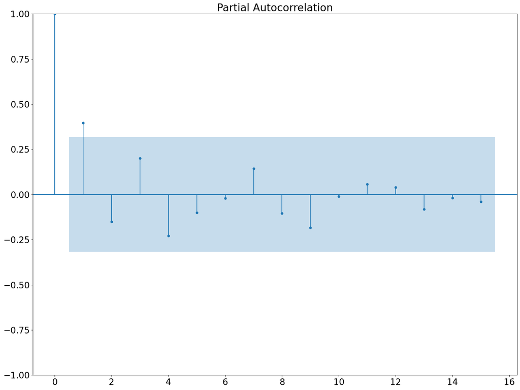

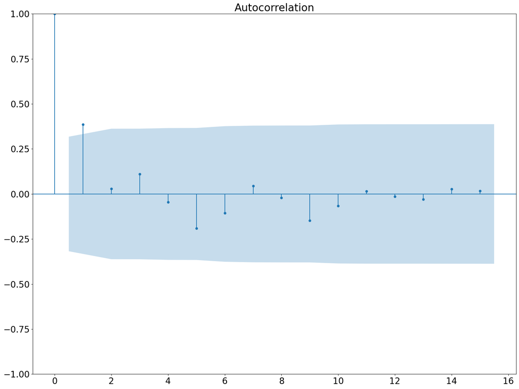

```python
plot_pacf(df_usa['Diff_Value'][2:] ,  lags = 15)
plot_acf(df_usa['Diff_Value'][2:] ,  lags = 15)
plt.show()
```

**The possible pairs of orders for ARIMA model can be :- (1,0,0) , (0,0,1) , (1,0,1)**

### Finding The Suitable Model

```python
orders= [(1,0,0) , (0,0,1) , (1,0,1)]

for order in orders:
    ar,ma = order[0] , order[-1]
    arima = ARIMA(df_usa['Diff_Value'][2:] , order = (ar,0,ma))
    results = arima.fit()
    print(f'ARIMA{order} has LLF = {results.llf} and AIC = {results.aic}')
```

```
ARIMA(1, 0, 0) has LLF = -630.4951395027682 and AIC = 1266.9902790055364
ARIMA(0, 0, 1) has LLF = -628.6004715339824 and AIC = 1263.2009430679648
ARIMA(1, 0, 1) has LLF = -627.9866982944458 and AIC = 1263.9733965888915
```

**Let's choose ARIMA(1,0,1)**

```python
arima_101 = ARIMA(df_usa['Diff_Value'][2:] , order = (1,0,1))
results_101 = arima_101.fit()
```

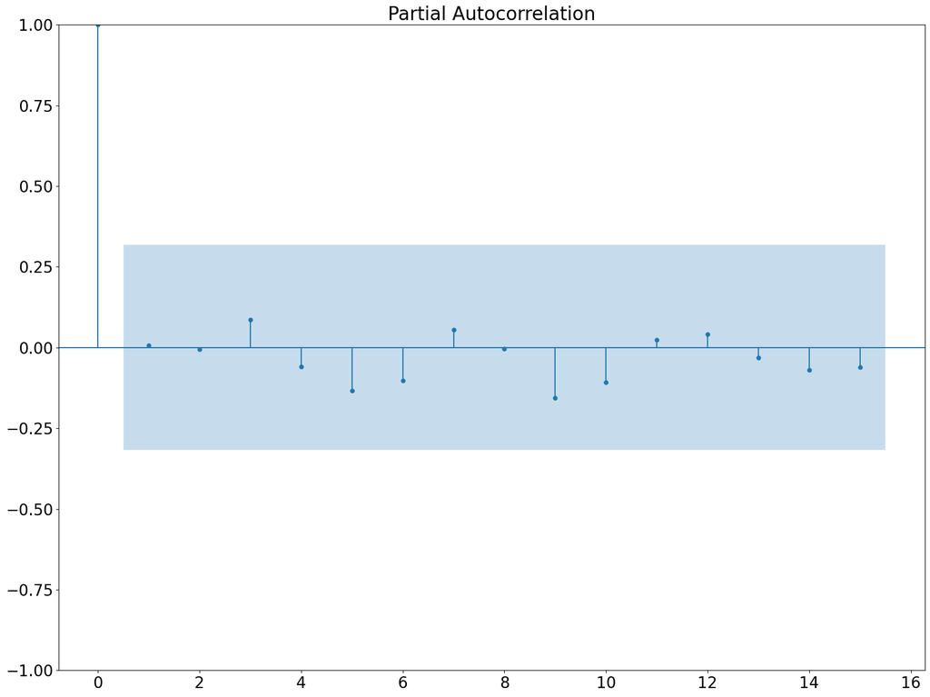

```python
plot_pacf(results_101.resid , lags = 15)
plt.show()

#we can proceed since there are no lags
```

### Forecasting Future Values

```python
# Lets forecast for next 15 months
differences = results_101.forecast(steps = 15).values.tolist()

# Store the data values for calculating values from forecast values
values = df_usa['Value'].values.tolist()
len(values)
```

```
40
```

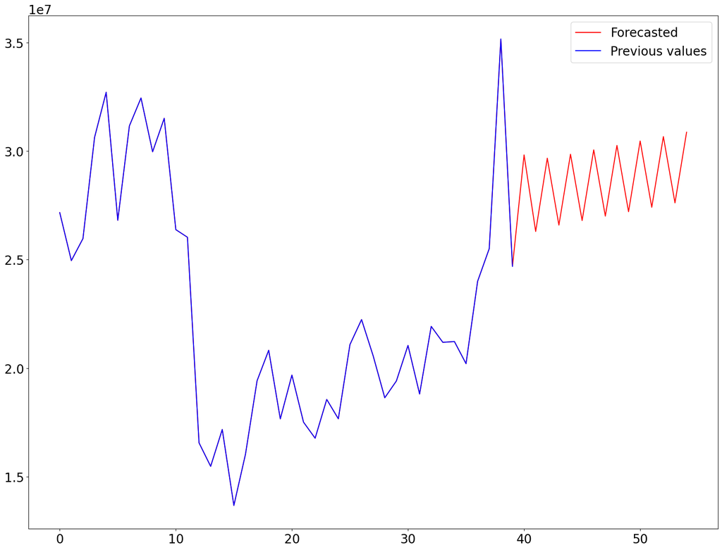

```python
for diff in differences:
    val = diff + values[-2]
    values.append(round(val))

plt.plot(values , label = 'Forecasted' , color = 'red')
plt.plot(df_usa['Value'].values , label = 'Previous values' ,color = 'blue')
plt.legend()
plt.show()
```

```python
forecast_df['USA'] = values[40:]
```

```python
# joblib.dump(results_101 , 'Model_USA.pkl')
```

[output not shown]

# Italy Country Analysis

### Data Preparation

```python
df_italy=data[data.Country == 'Italy'].drop('Country',axis = 1).set_index('Date').astype(int)
df_italy.head()
```

| Date | Value |
| --- | --- |
| 2019-01-01 | 3405980 |
| 2019-02-01 | 6455786 |
| 2019-03-01 | 4865427 |
| 2019-04-01 | 1503275 |
| 2019-05-01 | 2867990 |

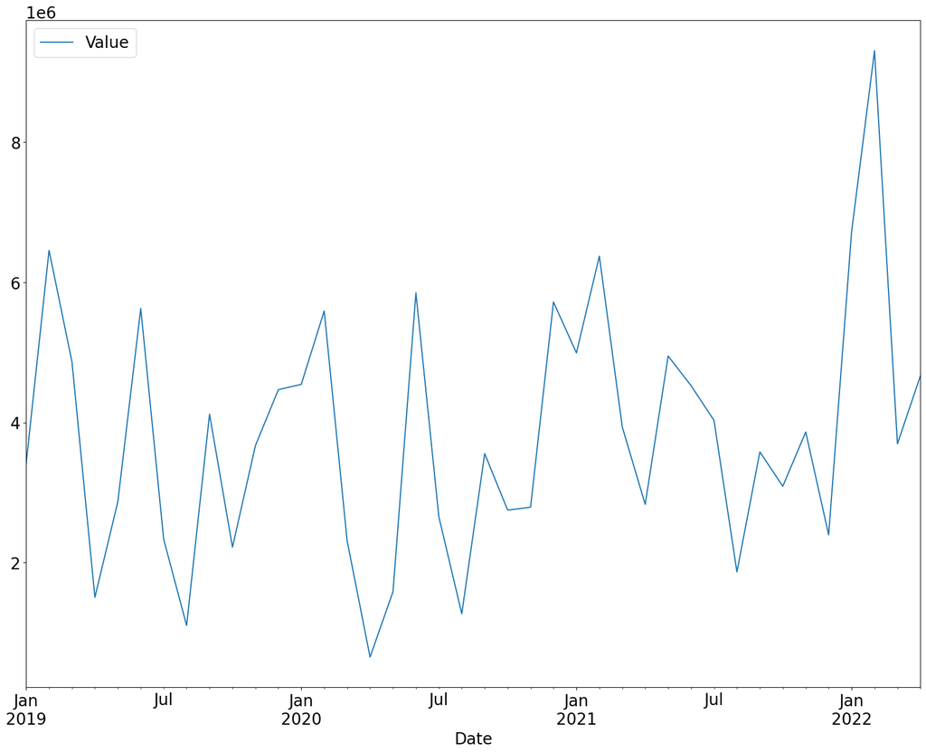

```python
df_italy.plot()
plt.show()
```

### Seasonal Decomposition Of Data

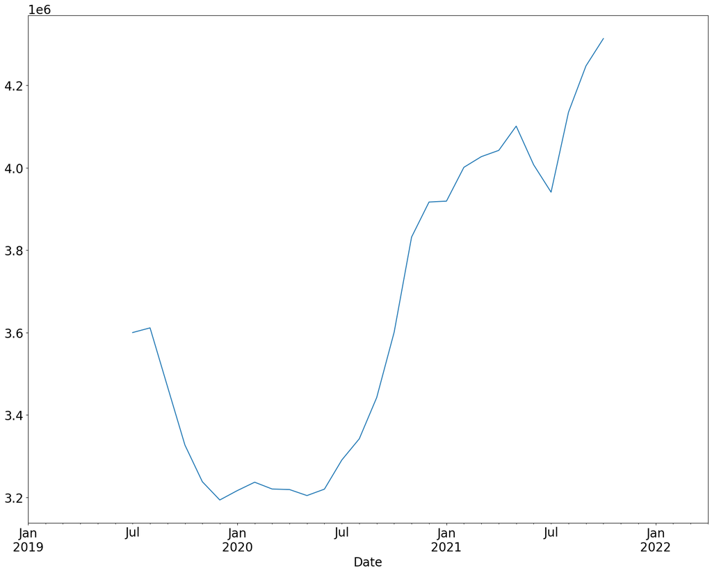

```python
decomposition = seasonal_decompose(df_italy['Value'] , model = 'additive')
decomposition.trend.plot()

plt.show()
```

### Check For Stationarity :- A D-Fuller Test

```python
result = sts.adfuller(df_italy['Value'])
print(f'ADF Statistic : {result[0]}')
print(f'n_lags: {result[2]}')
print(f'p_value: {result[1]}')

for key , value in result[4].items():
    print('Critical Values :')
    print(f'{key} , {value}')
```

```
ADF Statistic : -5.019925556758251
n_lags: 0
p_value: 2.02637896725765e-05
Critical Values :
1% , -3.610399601308181
Critical Values :
5% , -2.939108945868946
Critical Values :
10% , -2.6080629651545038
```

**Since p_value < 0.05 We reject the Null Hypotheses that Data is Non-Stationary**  
**Therefore Data is Stationary**

### Auto Correlation Function

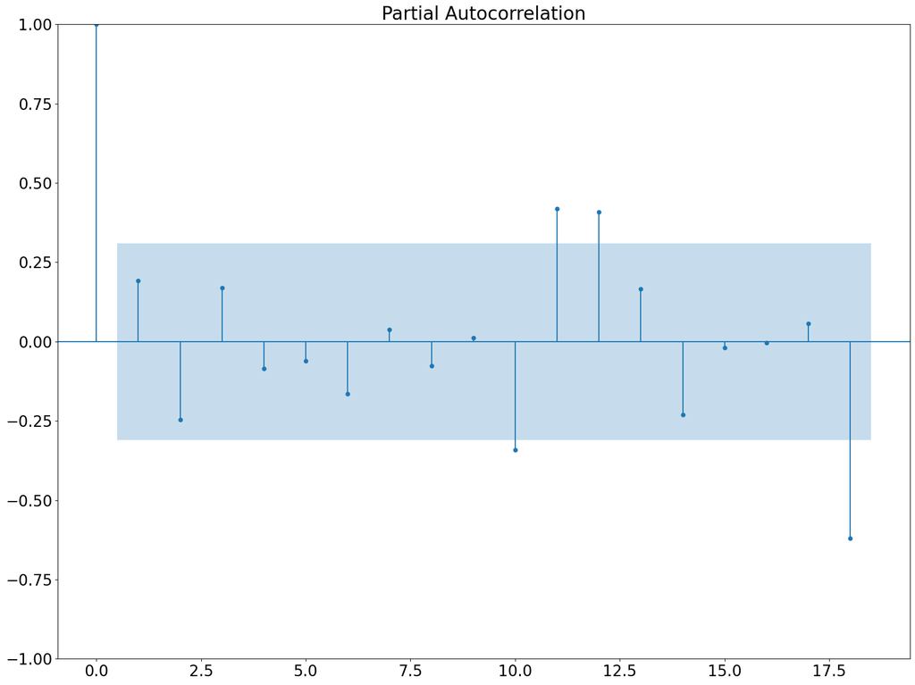

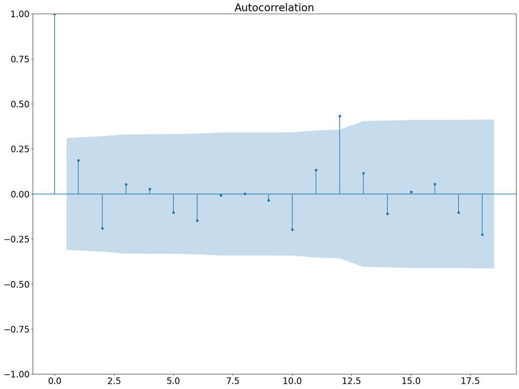

```python
plot_pacf(df_italy['Value'] , lags = 18)
plot_acf(df_italy['Value'] , lags = 18)
plt.show()
```

**We can see that there is no possible degree of similarity.....Lets get the Difference values**

### Differencing and Plotting ACF

```python
df_italy['Diff_Value'] = df_italy['Value'].diff()[1:]
df_italy.head()
```

| Date | Value | Diff_Value |
| --- | --- | --- |
| 2019-01-01 | 3405980 | NaN |
| 2019-02-01 | 6455786 | 3049806.0 |
| 2019-03-01 | 4865427 | -1590359.0 |
| 2019-04-01 | 1503275 | -3362152.0 |
| 2019-05-01 | 2867990 | 1364715.0 |

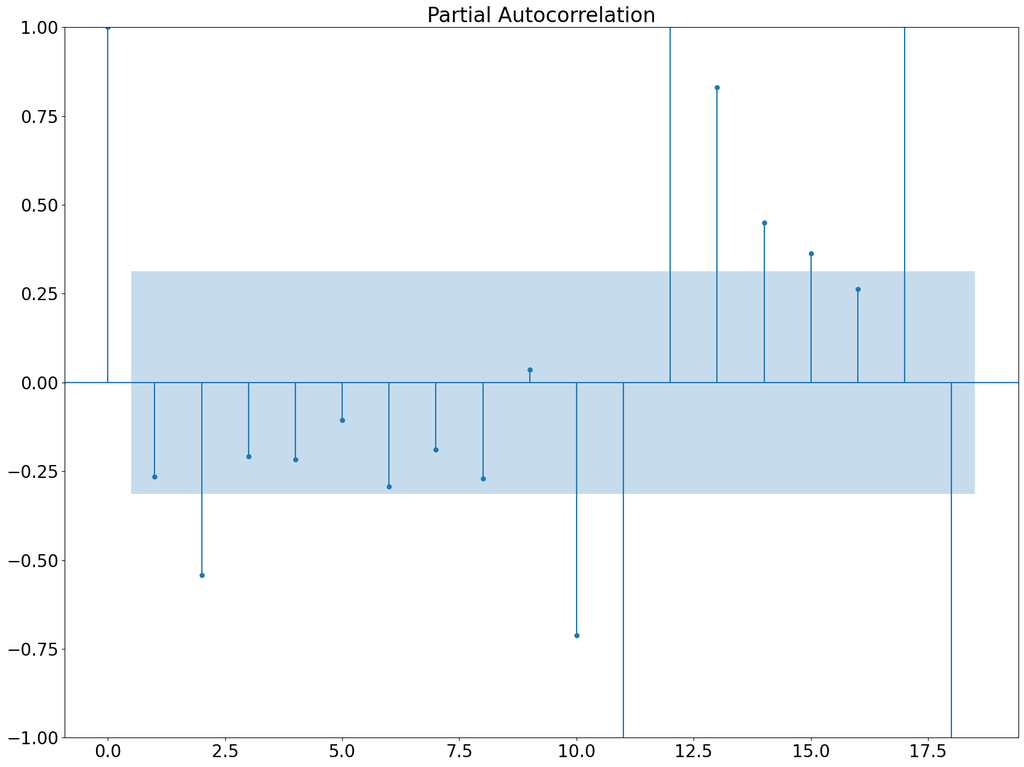

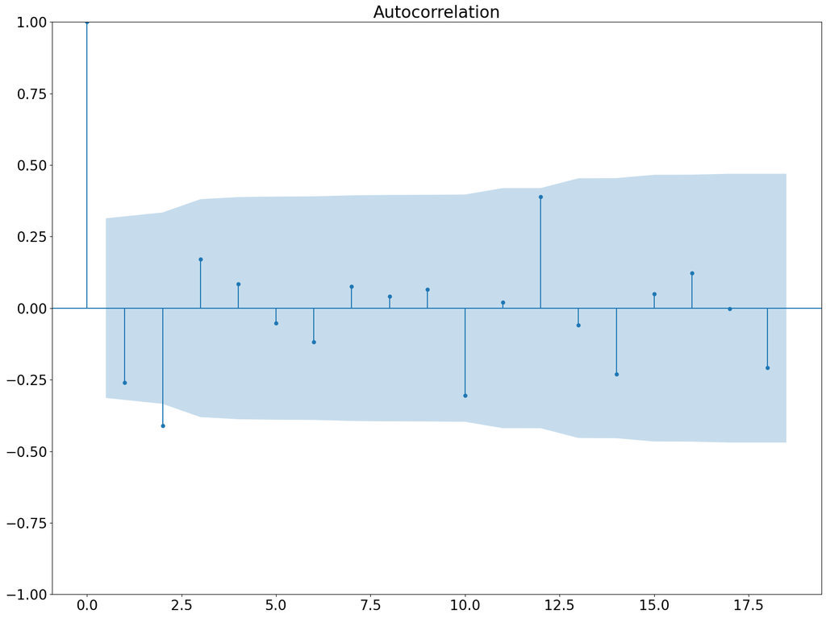

```python
plot_pacf(df_italy['Diff_Value'][1:] , lags = 18)
plot_acf(df_italy['Diff_Value'][1:] , lags = 18)
plt.show()
```

By see the pacf and acf plots we can have 3 pairs of orders for ARIMA model :-  
(2,0,0) , (2,0,2) , (0,0,2)